# R Notebook

# Introduction

Welcome! This model is used to calculate the carbon storage potential of a proposed agroforestry enhancement scheme in Morogoro, Tanzania for the Livelihoods Fund. The only thing you should need to change for this to work is the file path of the Params.R file (in the first block below).

## Reference Values

Reference values of Mg C/Ha for each environment were taken from the literature. These were:

- A static baseline value of 11.1 Mg C/Ha was taken from Muthuri et al. (2023), representing both above and belowground biomass from ‘Scattered Trees on Farms’.
- 31.9 Mg C/Ha for the spice-agroforestry system 30 years after planting, corresponding to ‘Perennial Tree-Crop Systems’ from Muthuri et al. (2023). No more specific references could be found for mature spice-agroforestry systems in this region.
- 25.5 Mg C/Ha for the woodlot system 5 years after planting, coming from a study which measured woodlot productivity in Morogoro, Tanzania (Kimaro et al., 2011). As this reference was only for aboveground biomass, it was multiplied by a default coefficient for the same tropical latitude from Cairns et al. (1997) of 1.24 to produce an estimate of below and aboveground carbon.

## Parameters Used

# The Model

## Initialisation

### Set the file paths and load libraries.

```r
# Clear environment
rm(list = ls())

setwd("~/Desktop/Coding/R_Studio/GLOFOR/Tanzania_updated")

# CHANGE PARAMETERS FILE PATH HERE
source("Params.R")

# Load packages
library(tidyverse)
```

### Set Timeframe

This sets the time frame to be run in the model.

```r
# Define the years until the maximum carbon value is reached for the agroforestry system after planting.
year <- c(0:years_to_carbon_plateau)

# Define the years of the crediting period, i.e the time over which the carbon storage should be calculated.
years_to_run <- c(1:years_to_crediting)
```

### Calculate the belowground biomass of biodiversity strips

Where no estimate of below ground biomass could be found, the aboveground biomass was multiplied by a scaling factor from Cairns et al. 1994.

```r
biodiversity_C <- biodiversity_C * 1.24 # Carins et al., 1994 (used in Henry et al.)
woodlot_C <- woodlot_C * 1.24
```

### Subtract baseline

The baseline value was subtracted from the agroforestry and woodlot reference values at the beginning of the model such that only additional carbon storage was considered. This was done as the design intended to increase tree cover and carbon storage starting from the baseline level in which there was likely to be some scattered trees on the farms. Therefore, in all plots and calculations in the model a value of 0 Mg C/Ha corresponds to the baseline.

```r
# Subtract baseline
woodlot_C <- woodlot_C - baseline_C
biodiversity_C <- biodiversity_C - baseline_C
agroforestry_C <- agroforestry_C - baseline_C
```

### Calculate Agroforestry Area

```r
agroforestry_percent <- 1 - woodlot_percent - biodiversity_percent
```

### Calculate Area of Each Land-Use to be Planted

```r
woodlot_area <- target_total_area*woodlot_percent
agroforestry_area <- target_total_area*agroforestry_percent
biodiversity_area <- target_total_area*biodiversity_percent
```

## Planting Rate Model

Planting rates were simulated through time, using a Gaussian function with peak ($\mu$) at 3 years after project initialisation and standard deviation ($\sigma$) of 5 (equation 1, figure 1).

Eq. 1

$$A(t) = a \cdot e^{-\frac{(t-\mu)^2}{2\sigma^2}}$$

Where: - $A(t)$: Area planted in year $t$ - $a$: Scaling factor - $\mu$: Peak planting year (mean of the distribution) - $\sigma$: Spread of planting (standard deviation)

Eq. 1

The scaling factor was calculated which minimised the difference between the integrated function and the target area to be planted (equation 2). This allowed us to dynamically alter the function by setting the area desired. For agroforestry systems, replanting is often required. In the model 10% of the planted area was replanted every 5 years.

Eq. 2

$$f(a) = \left| \sum_{t \in T} A(t) - A_{\text{target}} \right|$$

Where: - $T$: The range of years considered - $A_{\text{target}}$: The target area to be planted over 30 years

### Planting Rates Agroforestry

This is the initial Gaussian function used to show the planting rate’s early peak and steady decline.

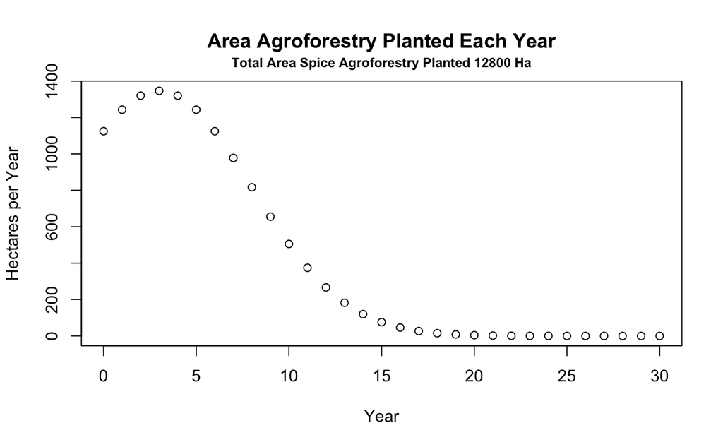

```r
# Define the Gaussian Planting Model
planting_agroforestry <- function(t, a, mu, sigma) {
  a * exp(-((t - mu)^2) / (2 * sigma^2))
}

# Function to calculate required 'a' for target total area
calculate_a <- function(target_total, year_range, mu, sigma) {
  # Initial guess for 'a'
  a_guess <- 1

  # Define function to minimize (difference between target and calculated total area)
  f <- function(a) {
    year_area_agroforestry <- sapply(year_range, planting_agroforestry, a = a, mu = mu, sigma = sigma)
    return(abs(sum(year_area_agroforestry) - target_total))
  }

  # Optimize 'a'
  opt_result <- optimize(f, interval = c(0, 1e6))
  return(opt_result$minimum)
}

# Calculate 'a' dynamically
a <- calculate_a(agroforestry_area, year, mu, sigma)

# Compute area planted each year
year_area_agroforestry <- sapply(year, planting_agroforestry, a = a, mu = mu, sigma = sigma)

# Calculate total area planted
total_area <- sum(year_area_agroforestry)

# Plot the data
plot(year, year_area_agroforestry,
     xlab = "Year", ylab = "Hectares per Year",
     main = "Area Agroforestry Planted Each Year",
     ylim = c(0, max(year_area_agroforestry)))

# Subtitle
mtext(paste("Total Area Spice Agroforestry Planted", round(total_area, 2), "Ha"),
      side = 3, line = 0.5, font = 2, cex = 0.8)
```

### Replanting Agroforestry

This is the replanting function used to cause 10% of the area planted to reoccur every 5 years.

```r
replanting_function <- function(values, years, interval, intensity) {
  if (length(values) != length(years)) {
    stop("Values and years must have the same length")
  }

  # Assume the first year as the baseline
  base_year <- min(years)
  replanting_area <- rep(0, length(years))  # Initialize output vector with zeros

  for (i in seq_along(years)) {
    year <- years[i]

    # Skip years before the first interval
    if (year < base_year + interval) {
      next
    }

    # Look for original values only, applying decay at fixed intervals
    for (j in seq_along(years)) {
      original_year <- years[j]

      if (original_year + interval <= year && (year - original_year) %% interval == 0) {
        replanting_area[i] <- replanting_area[i] + (intensity * values[j])
      }
    }
  }

  return(replanting_area)
}

replanting_area <- replanting_function(year_area_agroforestry, year, replanting_interval, replanting_intensity)

# Add the replanting area to the final agroforestry area
year_area_agroforestry_with_replanting <- year_area_agroforestry + replanting_area

# Plot the original data
plot(year, year_area_agroforestry,
     xlab = "Year", ylab = "Hectares per Year",
     main = "Area Agroforestry Planted Each Year",
     pch=16,
     ylim = c(0, max(year_area_agroforestry, replanting_area))) # Ensure y-axis fits both datasets  # Black line and dots for original values

# Overlay the adjusted (decayed) values
points(year, replanting_area, col = "blue", pch=16)  # Dashed blue line for decayed values
```

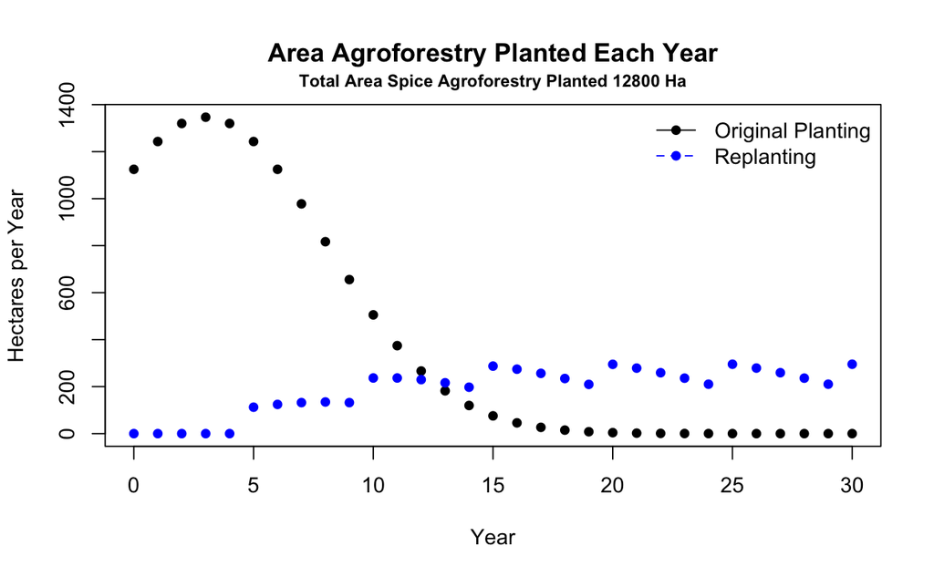

```r
# Subtitle with total area
mtext(paste("Total Area Spice Agroforestry Planted", round(total_area, 2), "Ha"),
      side = 3, line = 0.5, font = 2, cex = 0.8)

# Add a legend
legend("topright", legend = c("Original Planting", "Replanting"),
       col = c("black", "blue"), pch = 16, lty = c(1, 2), bty = "n")
```

### Fixed Area Planting biodiversity

This is for the biodiversity area, which was left out in the final model.

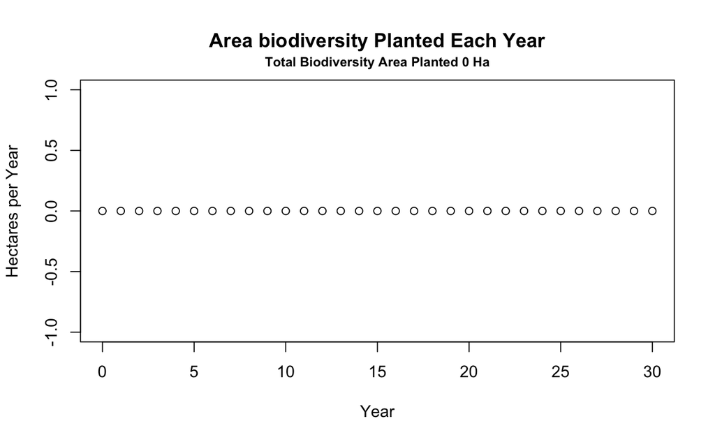

```r
# Define the Gaussian Planting Model
planting_biodiversity <- function(t, a, mu, sigma) {
  a * exp(-((t - mu)^2) / (2 * sigma^2))
}

# Function to calculate required 'a' for target total area
calculate_a <- function(target_total, year_range, mu, sigma) {
  # Initial guess for 'a'
  a_guess <- 1

  # Define function to minimize (difference between target and calculated total area)
  f <- function(a) {
    year_area_biodiversity <- sapply(year_range, planting_biodiversity, a = a, mu = mu, sigma = sigma)
    return(abs(sum(year_area_biodiversity) - target_total))
  }

  # Optimize 'a'
  opt_result <- optimize(f, interval = c(0, 1e6))
  return(opt_result$minimum)
}

# Calculate 'a' dynamically
a <- calculate_a(biodiversity_area, year, mu, sigma)

# Compute area planted each year
year_area_biodiversity <- sapply(year, planting_biodiversity, a = a, mu = mu, sigma = sigma)

if (biodiversity_percent ==0){
  year_area_biodiversity <- 0*year_area_biodiversity
}

# Calculate total area planted
total_area <- sum(year_area_biodiversity)

# Plot the data
plot(year, year_area_biodiversity,
     xlab = "Year", ylab = "Hectares per Year",
     main = "Area biodiversity Planted Each Year",
     ylim = c(0, max(year_area_biodiversity)))

# Subtitle
mtext(paste("Total Biodiversity Area Planted", round(total_area, 2), "Ha"),
      side = 3, line = 0.5, font = 2, cex = 0.8)
```

### Fixed Area Planting woodlots

This is the planting scheme for the woodlots, it uses the same method as the agroforestry.

```r
# Define the Gaussian Planting Model
planting_woodlot <- function(t, a, mu, sigma) {
  a * exp(-((t - mu)^2) / (2 * sigma^2))
}

# Function to calculate required 'a' for target total area
calculate_a <- function(target_total, year_range, mu, sigma) {
  # Initial guess for 'a'
  a_guess <- 1

  # Define function to minimize (difference between target and calculated total area)
  f <- function(a) {
    year_area_woodlot <- sapply(year_range, planting_woodlot, a = a, mu = mu, sigma = sigma)
    return(abs(sum(year_area_woodlot) - target_total))
  }

  # Optimize 'a'
  opt_result <- optimize(f, interval = c(0, 1e6))
  return(opt_result$minimum)
}

# Calculate 'a' dynamically
a <- calculate_a(woodlot_area, year, mu, sigma)

# Compute area planted each year
year_area_woodlot <- sapply(year, planting_woodlot, a = a, mu = mu, sigma = sigma)

# Calculate total area planted
total_area <- sum(year_area_woodlot)
```

### Plot Planting Timelines

This graphs the planting cumulatively over time.

```r
#Calculate total area planted
total_area_each_year <- year_area_agroforestry_with_replanting + year_area_biodiversity + year_area_woodlot
cumulative_area_agro <- cumsum(year_area_agroforestry_with_replanting)
cumulative_area_biodiversity <- cumsum(year_area_biodiversity)
cumulative_area_woodlot <- cumsum(year_area_woodlot)
cumulative_area <- cumsum(total_area_each_year)

# Plot
plot(
  years_to_run,
  cumulative_area_agro[2:31],
  type = "l",
  col = "purple",
  lwd = 2,
  main = paste("Total Area Planted Over", max(years_to_run), "Years:", target_total_area, "Ha"),
  xlab = "Year",
  ylab = "Total Area (Ha)",
  ylim = c(0, max(cumulative_area) )
)

# Add additional lines
lines(years_to_run, cumulative_area_woodlot[2:31], col = "blue", lwd = 2)
```

```r
lines(years_to_run, cumulative_area_biodiversity[2:31] , col = "green", lwd = 2)
lines(years_to_run, cumulative_area[2:31] , col = "black", lwd = 2)
```

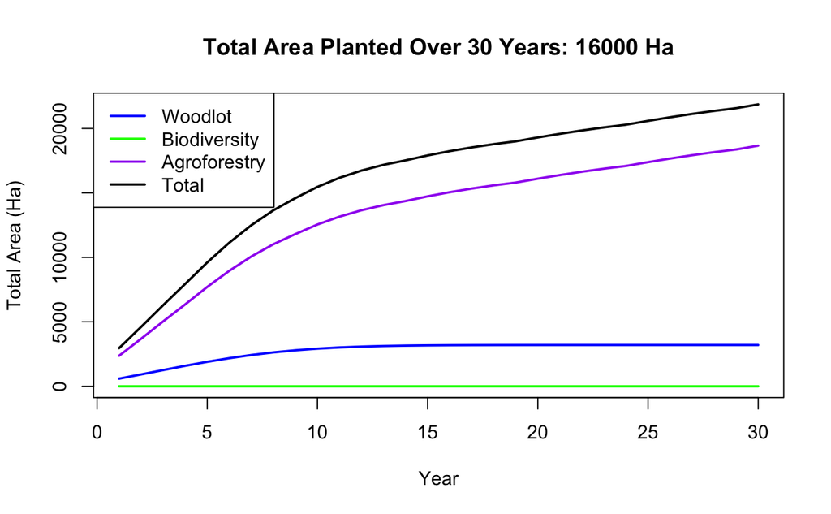

```r
# Add legend
legend("topleft", legend = c("Woodlot", "Biodiversity", "Agroforestry", "Total"),
       col = c("blue", "green", "purple", "black"), lwd = 2)
```

## Carbon Accumulation Model

The Chapman-Richards curve was used to model growth rates in both the agroforestry systems and woodlots over 30 years (Equation 3, figure 3, Pienaar and Turnbull, 1973).

Eq. 3

$$C(t) = C_{\text{max}} \times \left(1 - e^{-k t}\right)^p$$

Where: • $C(t)$: Carbon accumulated at time $t$ • $C_{\text{max}}$: Maximum carbon storage = 20.8 • $k$: Growth rate parameter = 0.2 • $p$: Shape parameter • $e$: Euler’s constant

### Carbon Accumulation in the Agroforestry System

For the agroforestry system the reference carbon density value from Muthuri et al. (2023) was set as the maximum after 30 years. Reyes et al. (2009) reported biomass accumulation in Gliricidia spice-agroforestry systems in Tanzania 6 years after planting of 9.54 Mg C/Ha. The system reported by Reyes et al. is very similar to the proposed spice system, but it reported the carbon storage after 6 years and not at maturity.

Therefore, it was decided to find a shape parameter $p$ which would cause the function to meet the reference value of 9.54 Mg C/Ha at 6 years from planting (figure 3). Rearranging Equation 3 to solve for $p$ produces an equation which cannot be solved algebraically. Therefore, Equation 4 was solved using a root-finding algorithm (uniroot in R) to find the value of $p$ for which $f(p) = 0$.

This gives the value of $p$ for which the difference between the Chapman-Richards equation and the target value is approximately zero. This value of $p$ was then used in Equation 3 to calculate the carbon accumulation over time for the agroforestry system.

Eq. 4

$$f(p) = C_{\text{max}} \times \left(1 - e^{-6k}\right)^p - 9.54$$

```r
# Define the function to solve for p
solve_p <- function(p, x_target, y_target, max, k) {
  return(max * (1 - exp(-k * x_target))^p - y_target)
}

# Find the correct p value
adjusted_p <- uniroot(solve_p, interval = c(0.1, 10), x_target = 6, y_target = 9.5424,
                       max = agroforestry_C, k = k_agroforestry)$root

# Define Chapman-Richards function with auto-adjusted p
chapman_richards <- function(x, max, k, p) {
  return(max * (1 - exp(-k * x))^p)
}

# Calculate carbon accumulation using the optimized p value
year_C_agro <- sapply(year, function(i) chapman_richards(i, max = agroforestry_C,
                                                          k = k_agroforestry, p = adjusted_p))

# Plot carbon accumulation
plot(year, year_C_agro, col = "blue", lwd = 2,
     main = paste("Carbon Accumulation Over", length(years_to_run), "Years in Agroforestry After Planting"),
     xlab = "Year", ylab = "Mg C/Ha")

# Add two dotted black lines converging at (6, 9.5424)
segments(x0 = 6, y0 = 0, x1 = 6, y1 = 9.5424, col = "black", lty = 2, lwd = 2)  # First line
```

```r
segments(x0 = 0, y0 = 9.5424, x1 = 6, y1 = 9.5424, col = "black", lty = 2, lwd = 2)  # Second line

# Add an arrow pointing to (6, 9.5424)
arrows(x0 = 8, y0 = 11, x1 = 6.3, y1 = 9.8, col = "black", lwd = 2, length = 0.1)
```

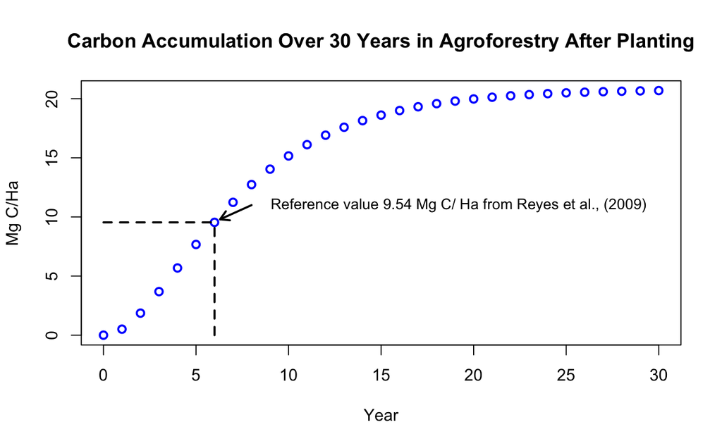

```r
# Add a label next to the arrow
text(x = 8.5, y = 11, labels = "Reference value 9.54 Mg C/ Ha from Reyes et al., (2009)", col = "black", pos = 4, cex = 0.9)
```

### Model of Carbon Accumulation in Woodlots

The average carbon stock over the 30-year period was taken to represent a stable measure of the carbon present in the woodlots.

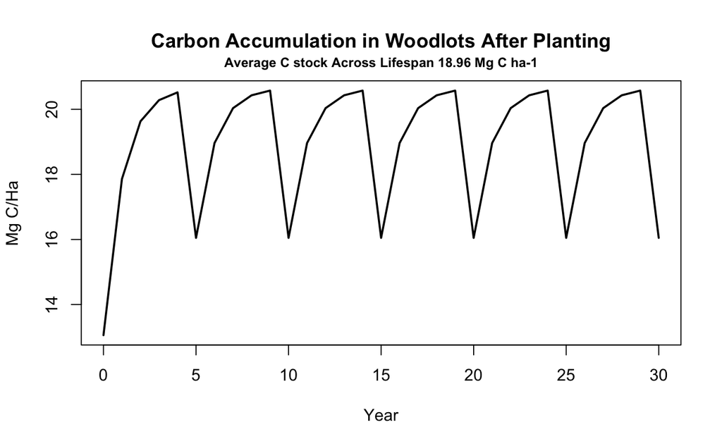

```r
# Calculate carbon accumulation
year_C_woodlot_5 <- c()
year_C_woodlot_10 <- c()

#Define function to find the max C at which the reference level is met after 5 years
chapman_richards_woodlot <- function(x, max = woodlot_C, k, p, rotation_period) {
  # Solve for max carbon storage (C_max)
  C_max <- woodlot_C / ((1 - exp(-k * rotation_period))^p)

  # Standard Chapman-Richards growth function
  base_growth <- C_max * (1 - exp(-k * x))^p

  return(base_growth)
}

# First rotation
for (i in 1:5) {
  year_C_woodlot_5 <- append(year_C_woodlot_5, chapman_richards_woodlot(i, max = woodlot_C, k = k_woodlot, p = p_woodlot, rotation_period))
}

# Second rotation
for (i in 1.5:6) {
  year_C_woodlot_10 <- append(year_C_woodlot_10, chapman_richards_woodlot(i, max = woodlot_C, k = k_woodlot, p = p_woodlot, rotation_period))
}

# Add the rotations together
year_C_woodlot_25 <- rep(year_C_woodlot_10, (length(year))/5)
year_C_woodlot <- append(year_C_woodlot_5, year_C_woodlot_25)
year_C_woodlot <- year_C_woodlot[1:31]

# This averages the standing biomass across all years
avg_woodlot_C <- mean(year_C_woodlot)
avg_woodlot_C_vect <- rep(avg_woodlot_C, length(years_to_run))

# This takes the total productivity (i.e sums the peaks)
max_value <- max(year_C_woodlot) # Find the maximum value
max_count <- sum(year_C_woodlot == max_value) # Count occurrences of the maximum value
# Sum the peaks of all the second rotations and then add the peak of the first rotatian and the final value at 30 years
total_woodlot_C <- woodlot_C*max_count + year_C_woodlot[31] + max(year_C_woodlot_5)
total_woodlot_C_vect <- rep(total_woodlot_C, length(years_to_run))

# Plot carbon accumulation
plot(year, year_C_woodlot, col = "black", lwd = 2,
     main = "Carbon Accumulation in Woodlots After Planting",
     xlab = "Year", ylab = "Mg C/Ha", type="l")

# Subtitle
mtext(paste("Average C stock Across Lifespan", round(avg_woodlot_C, 2), "Mg C ha-1"), side = 3, line = 0.5, font = 2, cex = 0.8)
```

### Model of C Accumulation in the Biodiversity

This section isn’t used but is the same method as the agroforestry.

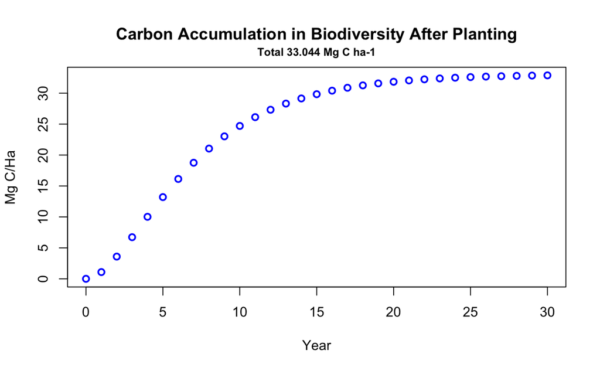

```r
chapman_richards <- function(x, max, k, p) {
  return(max * (1 - exp(-k * x))^p)
}

# Calculate carbon accumulation
year_C_biodi <- c()

for (i in year) {
  year_C_biodi <- append(year_C_biodi, chapman_richards(i, max = biodiversity_C, k = k_agroforestry, p = p))
}

# Plot carbon accumulation
plot(year, year_C_biodi, col = "blue", lwd = 2,
     main = "Carbon Accumulation in Biodiversity After Planting",
     xlab = "Year", ylab = "Mg C/Ha")

# Subtitle
mtext(paste("Total", biodiversity_C, "Mg C ha-1"), side = 3, line = 0.5, font = 2, cex = 0.8)
```

```r
NA
NA
NA
```

## Calculate the Total Carbon Storage for Each Land Use Type and Overall

Eq. 5

$$C_{i,t} = \sum_{\tau=1}^{t} A_{i,\tau} \cdot G_{i,t-\tau}$$

Where: • $t$: Year after planting on growth curves • $\tau$: Year since the beginning of the project • $C_{i,t}$: Carbon stored by land-use type $i$ in year $t$ • $A_{i,\tau}$: New hectares planted in year $\tau$ • $G_{i,t-\tau}$: Carbon accumulation per hectare in year $t-\tau$

```r
# Matrix for the results
total_yearly_C_mat <- matrix(0, nrow = 0, ncol = years_to_crediting + 1)

# Function to calculate yearly carbon for each land use
yearly_C_function <- function(area, carbon) {
  counter <- 0
  data_matrix <- matrix(0, nrow = years_to_crediting + 1, ncol = years_to_crediting + 1)

  # Go through the year_area_agroforestry_with_plantings and calculate yearly storage
  for (i in area[1:(years_to_crediting + 1)]) {
    # Multiply year_area_agroforestry_with_planting by growth curve, but only for the number of years left until the crediting period
    C_vect <- i * carbon[1:(years_to_crediting + 1 - counter)]

    # Add the vector to the matrix at the appropriate point, with 0s before it.
    data_matrix[counter + 1, (counter + 1):(years_to_crediting + 1)] <- C_vect

    # Update counter
    counter <- counter + 1
  }
    return(data_matrix)
}

yearly_C_matrix_agro <- yearly_C_function(year_area_agroforestry_with_replanting, year_C_agro)
yearly_C_matrix_bio <- yearly_C_function(year_area_biodiversity, year_C_biodi)
yearly_C_matrix_woodlot <- yearly_C_function(year_area_woodlot, year_C_woodlot)

total_C_vect_agro <- colSums(yearly_C_matrix_agro)
total_C_vect_bio <- colSums(yearly_C_matrix_bio)
total_C_vect_woodlot <- colSums(yearly_C_matrix_woodlot)

final_matrix <- rbind(total_C_vect_agro, total_C_vect_bio, total_C_vect_woodlot)
final_matrix <- rbind(final_matrix, colSums(final_matrix))
final_df <- as.data.frame(final_matrix)
rownames(final_df) <- c("Total C Agroforestry", "Total C Biodiversity", "Total C Woodlot",  "Total C")
final_df
```

|  | V1 | V2 | V3 | V4 | V5 | V6 | V7 | V8 | V9 | V10 | V11 | V12 | V13 | V14 | V15 | V16 | V17 | V18 | V19 | V20 | V21 | V22 | V23 | V24 | V25 | V26 | V27 | V28 | V29 | … |
| --- | --- | --- | --- | --- | --- | --- | --- | --- | --- | --- | --- | --- | --- | --- | --- | --- | --- | --- | --- | --- | --- | --- | --- | --- | --- | --- | --- | --- | --- | --- |
| Total C Agroforestry | 0.000 | 570.9036 | 2726.798 | 7132.277 | 14119.19 | 23741.60 | 35886.27 | 50311.17 | 66617.64 | 84303.79 | 102820.00 | 121675.78 | 140467.89 | 158830.50 | 176454.41 | 193098.73 | 208650.08 | 223104.93 | 236481.29 | 248809.8 | 260128.5 | 270536.41 | 280177.29 | 289159.46 | 297557.29 | 305417.56 | 312823.06 | 319885.99 | 326674.37 | … |
| Total C Biodiversity | 0.000 | 0.0000 | 0.000 | 0.000 | 0.00 | 0.00 | 0.00 | 0.00 | 0.00 | 0.00 | 0.00 | 0.00 | 0.00 | 0.00 | 0.00 | 0.00 | 0.00 | 0.00 | 0.00 | 0.0 | 0.0 | 0.00 | 0.00 | 0.00 | 0.00 | 0.00 | 0.00 | 0.00 | 0.00 | … |
| Total C Woodlot | 3672.241 | 9081.6366 | 15381.057 | 22094.954 | 28874.27 | 34144.85 | 39621.21 | 44740.74 | 49260.32 | 53093.36 | 54953.58 | 56859.71 | 58510.46 | 59865.79 | 60969.67 | 60594.05 | 60754.84 | 61104.42 | 61531.74 | 62001.6 | 61210.6 | 61110.19 | 61302.01 | 61637.75 | 62056.49 | 61238.03 | 61123.42 | 61308.18 | 61640.53 | … |
| Total C | 3672.241 | 9652.5401 | 18107.854 | 29227.231 | 42993.46 | 57886.44 | 75507.48 | 95051.92 | 115877.96 | 137397.15 | 157773.58 | 178535.49 | 198978.35 | 218696.29 | 237424.08 | 253692.78 | 269404.92 | 284209.36 | 298013.03 | 310811.4 | 321339.1 | 331646.59 | 341479.30 | 350797.21 | 359613.78 | 366655.59 | 373946.48 | 381194.16 | 388314.90 | … |

### Plot the Total Carbon Storage Over Time

```r
# Define colors for different carbon sources
colors <- c("red", "blue", "green", "black")  # Colors for each row

# Convert row names to a vector for legend
legend_labels <- rownames(final_df)

# Convert to numeric matrix (in case it's a dataframe)
final_matrix <- as.matrix(final_df)

# Define X-axis values
years_seq <- 0:(years_to_crediting)  # Adjusted to match column length

# Plot the first row of the dataframe as the base plot
plot(
  years_seq,
  final_matrix[1, ] / 1000000,  # Convert to Million Mg CO2
  type = "l",
  col = colors[1],
  lwd = 2,
  main = paste("Additional Carbon Stored after", length(years_seq), "years:",
               round(((final_matrix[4, ncol(final_matrix)] / 1000000)) * 3.67, 4), "(Million Mg CO2)"),
  xlab = "Year",
  ylab = "Total CO2 (Million Mg CO2)",
  ylim = c(0, max(final_matrix) / 1000000)  # Adjust Y-axis limits
)

# Add additional lines for each row in the dataframe
for (i in 2:4) {
  lines(years_seq, final_matrix[i, ] / 1000000, col = colors[i], lwd = 2)
}
```

[figure not shown]

```r
# Add legend
legend("topleft", legend = legend_labels, col = colors, lwd = 2)

# Subtitle showing average carbon stock
mtext(paste("Average Carbon Stock:", biodiversity_C, "Mg C ha-1"),
      side = 3, line = 0.5, font = 2, cex = 0.8)
```